This uses the heterogeneous skyride code from a nice [paper](http://arxiv.org/abs/1210.4908) by Julia Palacios and Vladimir Minin, which employs INLA to fit a skyride to a clock-like tree. I’ve cleaned the code a little, but it doesn’t deal with repeated sample times or repeated coalescence intervals.

As this is just a quick exploratory analysis, I cheat by adding in a small noise term to the branch lengths. For some reason, the `180914_HPTN071_scC_rep1-n0005_SIMULATED` scenario fails to converge with this approach; I’ll continue to look into this. It’ll be interesting to see how these results compare with the skyrides from BEAST. On first glance, however, there aren’t too many differences between them.

First, I load in a bunch of libraries.

```r
library(ape)
library(INLA)
```

```r
library(magrittr)
library(ggplot2)
```

The following are taken from Palacios and Minin.

```r
branching.sampling.times <- function(phy){
  phy = new2old.phylo(phy)
  if (class(phy) != "phylo")
    stop("object \"phy\" is not of class \"phylo\"")
  tmp <- as.numeric(phy$edge)
  nb.tip <- max(tmp)
  nb.node <- -min(tmp)
  xx <- as.numeric(rep(NA, nb.tip + nb.node))
  names(xx) <- as.character(c(-(1:nb.node), 1:nb.tip))
  xx["-1"] <- 0
  for (i in 2:length(xx)) {
    nod <- names(xx[i])
    ind <- which(phy$edge[, 2] == nod)
    base <- phy$edge[ind, 1]
    xx[i] <- xx[base] + phy$edge.length[ind]
  }
  depth <- max(xx)
  branching.sampling.times <- depth - xx
  return(branching.sampling.times)
}
```

```r
heterochronous.gp.stat <- function(phy){
  b.s.times = branching.sampling.times(phy)
  int.ind = which(as.numeric(names(b.s.times)) < 0)
  tip.ind = which(as.numeric(names(b.s.times)) > 0)
  num.tips = length(tip.ind)
  num.coal.events = length(int.ind)
  sampl.suf.stat = rep(NA, num.coal.events)
  coal.interval = rep(NA, num.coal.events)
  coal.lineages = rep(NA, num.coal.events)
  sorted.coal.times = sort(b.s.times[int.ind])
  names(sorted.coal.times) = NULL
  #unique.sampling.times = sort(unique(b.s.times[tip.ind]))
  sampling.times = sort((b.s.times[tip.ind]))
  for (i in 2:length(sampling.times)){
   if ((sampling.times[i]-sampling.times[i-1])<0.1){
     sampling.times[i]<-sampling.times[i-1]}
  }
  unique.sampling.times<-unique(sampling.times)
  sampled.lineages = NULL
  for (sample.time in unique.sampling.times){
   sampled.lineages = c(sampled.lineages,
    sum(sampling.times == sample.time))
  }
return(list(coal.times=sorted.coal.times, sample.times = unique.sampling.times, sampled.lineages=sampled.lineages))
}
```

```r
calculate.heterochronous.skyride <- function(tree){
  ##Data prep to use INLA
  dd<-heterochronous.gp.stat(tree)
  s.time<-dd$sample.times
  n.sample<-dd$sampled.lineages
  n<-length(dd$coal.times)+1
  data<-matrix(0,nrow=n-1,ncol=2)
  data[,1]<-dd$coal.times
  s.time<-c(s.time,max(data[,1])+1)
  data[1,2]<-sum(n.sample[s.time<=data[1,1]])
  tt<-length(s.time[s.time<=data[1,1]])+1
  for (j in 2:nrow(data)){
    if (data[j,1]<s.time[tt]){
      data[j,2]<-data[j-1,2]-1
        }else{
            data[j,2]<-data[j-1,2]-1+sum(n.sample[s.time>data[j-1,1] & s.time<=data[j,1]])
          tt<-length(s.time[s.time<=data[j,1]])+1
        }
  }
  ###Bayesian Skyride -CGGP
  s<-unique(sort(c(data[,1],s.time[1:length(s.time)-1])))
  event1<-sort(c(data[,1],s.time[1:length(s.time)-1]),index.return=TRUE)$ix
  n<-nrow(data)+1
  l<-length(s)
  event<-rep(0,l)
  event[event1<n]<-1
  y<-diff(s)
  coal.factor<-rep(0,l-1)
  indicator<-rep(0,l-1)
  t<-rep(0,l-1)
  indicator<-cumsum(n.sample[s.time<data[1,1]])
  indicator<-c(indicator,indicator[length(indicator)]-1)
  ini<-length(indicator)+1
  for (k in ini:(l-1)){
    j<-data[data[,1]<s[k+1] & data[,1]>=s[k],2]
    if (length(j)==0){indicator[k]=indicator[k-1]+sum(n.sample[s.time<s[k+1] & s.time>=s[k]])}
    if (length(j)>0){indicator[k]<-j-1+sum(n.sample[s.time<s[k+1] & s.time>=s[k]])}
  }
  coal.factor<-indicator*(indicator-1)/2
  coal.times<-data[,1]
  u<-c(coal.times[1],diff(coal.times))
  label<-c(1,1+cumsum(event[1:(l-1)]))
  factor.matrix<-.5*diag(length(u))
  for (j in 2:length(u)){
    for (i in 1:(j-1)){
      factor.matrix[j,i]<-1
    }
  }
  time_aware_short<-factor.matrix%*%u
  time_aware<-time_aware_short[label]
  E <- y*coal.factor
  formula=y~-1+f(time,model="rw1",hyper = list(prec = list(param = c(.001, .001))),constr=FALSE)
  data_mod<-data.frame(y=event[-1],event=event[-1],time=time_aware[-1],E=log(E))
  mod5<-inla(formula,family="poisson",data=data_mod,offset=E,control.predictor=list(compute=TRUE))
  grid.points.scaled1<-dd$coal.times
  sr.median <- exp(-mod5$summary.random$time$"0.5quant")
  sr.lc <- exp(-mod5$summary.random$time$"0.025quant")
  sr.uc <- exp(-mod5$summary.random$time$"0.975quant")
  data.frame(time=grid.points.scaled1,sr.median=sr.median,sr.lc=sr.lc,sr.uc=sr.uc)
}
```

Next, I load in the clock-like trees generated by LSD.

```r
lsd.dirs <- list.dirs("../lsd")
lsd.dirs <- lsd.dirs[2:length(lsd.dirs)]
stubs <- strsplit(lsd.dirs,"/") %>% lapply(.,"[",3) %>% unlist
trees.fn <- paste(lsd.dirs,"/",stubs,"_result_newick_date.txt",sep="")
numtrees <- length(trees.fn)
trees <- list()
for(i in 1:numtrees){
  trees[[i]] <- read.tree(trees.fn[i])
}
```

I loop through the trees and generate skyrides for each. Note how I omit tree number 3, which I can’t get to converge with INLA.

```r
set.seed(1)
srlist <- list()
epsvec <- rep(0.0001,15)
treevec <- c(1,2,4,5,6,7,8,9,10,11,12,13,14,15)
for(i in treevec){
  tr <- trees[[i]]
  eps <- epsvec[i]
  # The following is a hack to deal with repeated sample and coalescence times
  tr$edge.length <- tr$edge.length+runif(length(tr$edge.length),-eps,eps)
  # use tipdate.ci from phyext to calculate sample and coalescence times for heterochronous trees, as coalescent.intervals from ape doesn't work
  sr <- calculate.heterochronous.skyride(tr)
  srlist[[i]] <- sr
}
```

I have to do some data processing to get a format palatable for `ggplot2`.

```r
results <- srlist[[1]]
results$Scenario <- stubs[treevec[1]]
for(i in 2:length(treevec)){
  tv <- treevec[i]
  r <- srlist[[tv]]
  r$Scenario <- stubs[tv]
  results <- rbind(results,r)
}
```

Now I can plot out the results…

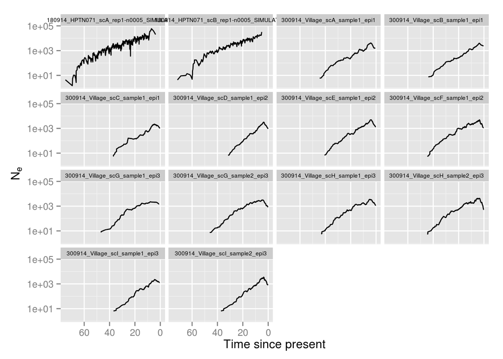

```r
p <- ggplot(data=results,aes(x=time))+geom_line(aes(y=sr.median))+facet_wrap(~Scenario)+ylab(expression(N[e]))+xlab("Time since present")+scale_y_log10()+scale_x_reverse()+theme(strip.text.x=element_text(size = rel(0.6)))
p
```

…as well as save them

```r
ggsave(filename="skyride.svg",plot=p,width=9,height=6)
```